# Intro to Lubridate

Tim Dennis

27 May, 2019

**Credits: Primarily taken from https://rpubs.com/joelrudinas03/422499 & Charlotte Wickham’s Lubridate Lesson on DataCamp**

## Learning Objectives

- Know and show difference between a date and time
- Practical lubridate examples - convert strings to dates, filter data frame by month,
- Time of day, etc.
- Basic date math
- ggplot - show how to format date labels properly (e.g by first day of month, or week)
- ggplot - geom_smooth (e.g. loess)

## Why lubridate?

- in this workshop we will focus alsmost exclusively on the R package `lubridate` when working with dates
- Designed to make working with dates in times easier
- It is part of the `tidyverse` package, what’s this?
- Plays nicely with other `tidyverse` packages
- just know there are base R ways of dealing with dates and times
- R doesn’t know something is a date unless you tell it.
- If you have a character string that represents a date in the **ISO 8601** standard you can turn it into a Date using the `as.Date()` base-R function or lubridate `ymd()` lubridate function
- Pass the character string (or a vector of character strings) as the first argument.
- Often when you read data in, R will try and make it’s best guess, esp if it is formatted well.
- For date-times R has the base functions `as.POSIXct()`, but we’ll use the suite of Lubridate functions like `ymd_hms()` to parse date-time objects

They have consistent behavior regardless of underlying object

```r
library(lubridate)
```

- `lubridate` contains many useful functions.
- We’ll only be covering the basics here.
- Type `help(package = lubridate)` to bring up an overview of the package, including the package DESCRIPTION, a list of available functions, and a link to the official package vignette.
- `today()` function returns today’s date

```r
#lets store in a var called `this_day`
this_day <- today()
this_day
```

```
## [1] "2019-05-27"
```

## Parsing dates

- In real wold date, when we work with dates they often come in many formats
- Lubridate let’s us parse these into date & date-time objects in R so we can work with them as dates.
- The parsing functions ln ubridates mirror the structure of the dates you want to parse.
- This works by suplementing the order in which the year (‘y’), month (‘m’) and day (‘d’) elements appear the string to be parsed:
  - so if we have a date that is orderd by year, then month, then day, we use `ymd()`
  - lubridate is smart enough to ignore the delimeter, e.g. `-`, `\`, etc. and grab the parts
- Lubridate provides: `dmy()`, `myd()`, `ymd()`, `ydm()`, `dym()`, `mdy()`, `ymd_hms()`). A very flexible and user friendly parser is provided by parse_date_time().

How does this work?

Example:

```r
# Parse x
x <- "2010 September 20th" # 2010-09-20
ymd(x)
```

```
## [1] "2010-09-20"
```

Now you:

For each date, the ISO 8601 format is displayed as a comment after it, to help you check your work:

Choose the correct function to parse y

```r
# Parse y
y <- "02.01.2010"  # 2010-01-02
___(y)
```

```r
# Parse z
z <- "Sep, 12th 2010 14:00"  # 2010-09-12T14:00
___(z)
```

What the solution for this?

```r
a <- "27 May 2019"
---(a)
```

## Use `parse_date_time` for things that don’t fit

- some time dates won’t fix what lubridate provides to parse or set the date data.
- in this case, lubridate provides `parse_date_time()` function where we can provide a pattern for lubridate
- to find a list of all the characters and what they mean, look at `?parse_date_time`
- I’m providing it here for ease, but if you get stuck in the future this is in the help doc

[output not shown]

```r
# Specify an order string to parse x
x <- "Monday May 26th 2019 at 1pm"
parse_date_time(x, orders = "amdyIp")
```

```
## [1] "2019-05-26 13:00:00 UTC"
```

- what if you have inconsistant date data? some in one format, other in another?
- here we can provide a vector of the different types and lubridate will figure it out!

```r
# Specify order to include both "mdy" and "dmy"
two_orders <- c("October 7, 2001", "October 13, 2002", "April 13, 2003",
  "17 April 2005", "23 April 2017")
parse_date_time(two_orders, orders = c("mdy", "dmy"))
```

```
## [1] "2001-10-07 UTC" "2002-10-13 UTC" "2003-04-13 UTC" "2005-04-17 UTC"
## [5] "2017-04-23 UTC"
```

- another example

```r
# Specify order to include "dOmY", "OmY" and "Y"
short_dates <- c("11 December 1282", "May 1372", "1253")
parse_date_time(short_dates, orders = c("dOmY", "OmY", "Y"))
```

```
## [1] "1282-12-11 UTC" "1372-05-01 UTC" "1253-01-01 UTC"
```

- your turn:

```r
## ** heterogenuous date-times **
x <- c("09-01-01", "090102", "09-01 03", "09-01-03 12:02")
parse_date_time(x, c("___", "______"))
```

## Read in weather data

- Import the daily data `akl_weather_daily.csv` with `read_csv()` - weather data in Auckland
- Print `akl_daily_raw` to confirm the date column hasn’t been interpreted as a date. Can you see why?
- Using `mutate()` overwrite the column date with a parsed version of date. You need to specify the parsing function. Hint: the first date should be September 1.
- Print `akl_daily` to verify the date column is now a Date.
- Take a look at the data by plotting date on the x-axis and max_temp of the y-axis.

```r
# Import CSV with read_csv()
akl_daily_raw <- read_csv("https://assets.datacamp.com/production/course_5348/datasets/akl_weather_daily.csv")
# Print akl_daily_raw
akl_daily_raw
```

```
## # A tibble: 3,661 x 7
##    date      max_temp min_temp mean_temp mean_rh events cloud_cover
##    <chr>        <dbl>    <dbl>     <dbl>   <dbl> <chr>        <dbl>
##  1 2007-9-1        60       51        56      75 <NA>             4
##  2 2007-9-2        60       53        56      82 Rain             4
##  3 2007-9-3        57       51        54      78 <NA>             6
##  4 2007-9-4        64       50        57      80 Rain             6
##  5 2007-9-5        53       48        50      90 Rain             7
##  6 2007-9-6        57       42        50      69 <NA>             1
##  7 2007-9-7        59       41        50      77 <NA>             4
##  8 2007-9-8        59       46        52      80 <NA>             5
##  9 2007-9-9        55       50        52      88 Rain             7
## 10 2007-9-10       59       50        54      82 Rain             4
## # … with 3,651 more rows
```

- in order to do this we’ll need to know some `dlpyr`, who’s knows dplyr?
- dplyr is a package in the tidyverse that let’s us manipulate dataframes
- dplyr Review
  - mutate() - add new columns (or overwrite old ones)
  - filter() - subset rows
  - select() - subset columns
  - arrange() - order rows
  - summarise() - summarise row
- Now we will use the dplyr `mutate` function to overwrite the dates with the right parse order
- another feature of dplyr and the tidyverse is the `%>%` pipe operator which let’s us set up chained operations that work on our date - read left to right, first take this data and do this, then that.
- let’s walk thru it:

```r
# Parse date
akl_daily <- akl_daily_raw %>%
  mutate(date = ymd(date))
```

- let’s see what it looks like now

```r
# Print akl_daily
akl_daily
```

```
## # A tibble: 3,661 x 7
##    date       max_temp min_temp mean_temp mean_rh events cloud_cover
##    <date>        <dbl>    <dbl>     <dbl>   <dbl> <chr>        <dbl>
##  1 2007-09-01       60       51        56      75 <NA>             4
##  2 2007-09-02       60       53        56      82 Rain             4
##  3 2007-09-03       57       51        54      78 <NA>             6
##  4 2007-09-04       64       50        57      80 Rain             6
##  5 2007-09-05       53       48        50      90 Rain             7
##  6 2007-09-06       57       42        50      69 <NA>             1
##  7 2007-09-07       59       41        50      77 <NA>             4
##  8 2007-09-08       59       46        52      80 <NA>             5
##  9 2007-09-09       55       50        52      88 Rain             7
## 10 2007-09-10       59       50        54      82 Rain             4
## # … with 3,651 more rows
```

- We can plot to see if it it works. How does this tell us?
- we’ll put date on the `x` axis and max_temp on the `y`

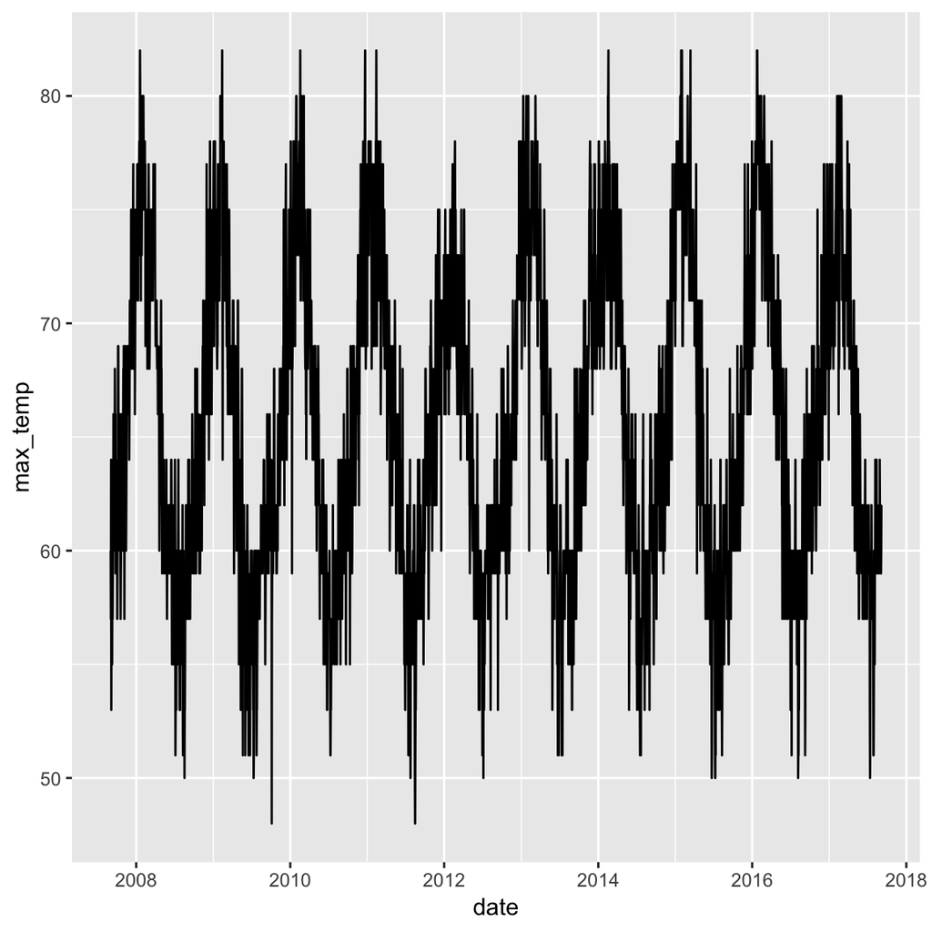

```r
# Plot to check work
ggplot(akl_daily, aes(x = date, y = max_temp)) +
  geom_line()
```

- we can see the summer winter cycle.

## Import hourly weather data

- Import the hourly data, `akl_weather_hourly_2016.csv` with `read_csv()`, then print `akl_hourly_raw` to confirm the date is spread over year, month and mday.

```r
# Import "akl_weather_hourly_2016.csv"
akl_hourly_raw <- read_csv("https://assets.datacamp.com/production/course_5348/datasets/akl_weather_hourly_2016.csv")
```

- notice the date components are spread across columns

```r
# Print akl_hourly_raw
akl_hourly_raw
```

```
## # A tibble: 17,454 x 10
##     year month  mday time  temperature weather conditions events humidity
##    <dbl> <dbl> <dbl> <drt>       <dbl> <chr>   <chr>      <chr>     <dbl>
##  1  2016     1     1 00:00        68   Clear   Clear      <NA>         68
##  2  2016     1     1 00:30        68   Clear   Clear      <NA>         68
##  3  2016     1     1 01:00        68   Clear   Clear      <NA>         73
##  4  2016     1     1 01:30        68   Clear   Clear      <NA>         68
##  5  2016     1     1 02:00        68   Clear   Clear      <NA>         68
##  6  2016     1     1 02:30        68   Clear   Clear      <NA>         68
##  7  2016     1     1 03:00        68   Clear   Clear      <NA>         68
##  8  2016     1     1 03:30        68   Cloudy  Partly Cl… <NA>         68
##  9  2016     1     1 04:00        68   Cloudy  Scattered… <NA>         68
## 10  2016     1     1 04:30        66.2 Cloudy  Partly Cl… <NA>         73
## # … with 17,444 more rows, and 1 more variable: date_utc <dttm>
```

- Using `mutate()` create the column date with using `make_date()`, which let’s us concatenate date components together

```r
# Use make_date() to combine year, month and mday
akl_hourly  <- akl_hourly_raw  %>%
  mutate(date = make_date(year = year, month = month, day = mday))
```

```r
akl_hourly
```

```
## # A tibble: 17,454 x 11
##     year month  mday time  temperature weather conditions events humidity
##    <dbl> <dbl> <dbl> <drt>       <dbl> <chr>   <chr>      <chr>     <dbl>
##  1  2016     1     1 00:00        68   Clear   Clear      <NA>         68
##  2  2016     1     1 00:30        68   Clear   Clear      <NA>         68
##  3  2016     1     1 01:00        68   Clear   Clear      <NA>         73
##  4  2016     1     1 01:30        68   Clear   Clear      <NA>         68
##  5  2016     1     1 02:00        68   Clear   Clear      <NA>         68
##  6  2016     1     1 02:30        68   Clear   Clear      <NA>         68
##  7  2016     1     1 03:00        68   Clear   Clear      <NA>         68
##  8  2016     1     1 03:30        68   Cloudy  Partly Cl… <NA>         68
##  9  2016     1     1 04:00        68   Cloudy  Scattered… <NA>         68
## 10  2016     1     1 04:30        66.2 Cloudy  Partly Cl… <NA>         73
## # … with 17,444 more rows, and 2 more variables: date_utc <dttm>,
## #   date <date>
```

- Now we need to paste together the date and time columns. Create datetime by parsing the `datetime_string` column.
- we can do this with another `mutate` and using the `paste` function (designed to paste strings together)
- then we add the proper lubricate datetime object

```r
# Parse datetime_string
akl_hourly <- akl_hourly  %>%
  mutate(
    datetime_string = paste(date, time, sep = "T"),
    datetime = ymd_hms(datetime_string)
  )
```

- Take a look at the date, time and datetime columns to verify they match up.
- Here we’ll use another `dplyr` function `select` to pull out only the columns we are interested in

```r
# Print date, time and datetime columns of akl_hourly
akl_hourly %>% select(date, time, datetime)
```

```
## # A tibble: 17,454 x 3
##    date       time   datetime
##    <date>     <drtn> <dttm>
##  1 2016-01-01 00:00  2016-01-01 00:00:00
##  2 2016-01-01 00:30  2016-01-01 00:30:00
##  3 2016-01-01 01:00  2016-01-01 01:00:00
##  4 2016-01-01 01:30  2016-01-01 01:30:00
##  5 2016-01-01 02:00  2016-01-01 02:00:00
##  6 2016-01-01 02:30  2016-01-01 02:30:00
##  7 2016-01-01 03:00  2016-01-01 03:00:00
##  8 2016-01-01 03:30  2016-01-01 03:30:00
##  9 2016-01-01 04:00  2016-01-01 04:00:00
## 10 2016-01-01 04:30  2016-01-01 04:30:00
## # … with 17,444 more rows
```

- finally let’s look at it on a plot
- Take a look at the data by plotting datetime on the x-axis and temperature of the y-axis.

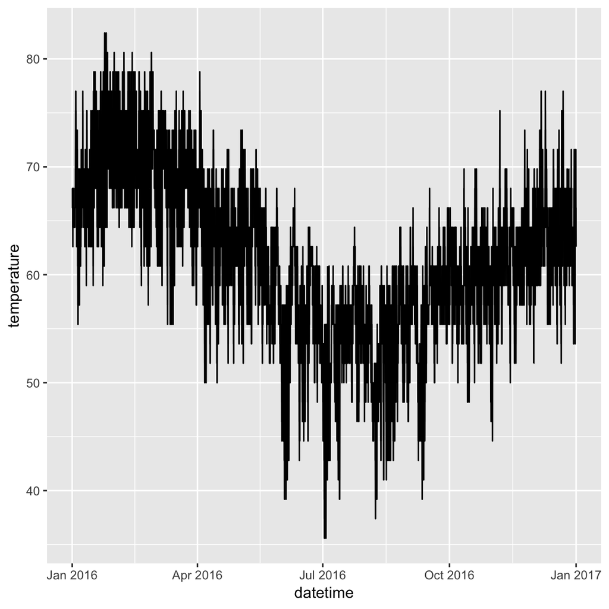

```r
# Plot to check work
ggplot(akl_hourly, aes(x = datetime, y = temperature)) +
  geom_line()
```

## Extracting parts of a datetime

- In lubridate, extracting parts of a datetime is easier
- So if we want to pull out the date information by year we use `year()`

```r
x <- ymd("2019-05-27")
```

```r
year(x)
```

```
## [1] 2019
```

- or month:

```r
month(x)
```

```
## [1] 5
```

What do you think if we want to pull out day? what would we do?

```r
day(x)
```

```
## [1] 27
```

- It is also possible to set parts of a datetime

```r
print(x)
```

```
## [1] "2019-05-27"
```

- i can set the year to 2017 instead.

```r
year(x) <- 2017
x
```

```
## [1] "2017-05-27"
```

## What can you extract?

- Before we begin this exercise, we must extract certain columns first.
- let’s read in the R release times dataset

```r
# Use read_csv() to import rversions.csv
releases <- read_csv("https://assets.datacamp.com/production/course_5348/datasets/rversions.csv")
```

- Let’s pull out the `datetime` column from releases

```r
release_time <- releases$datetime
```

- Examine the head() of release_Time to verify this is a vector of datetimes

```r
head(release_time)
```

```
## [1] "1997-12-04 08:47:58 UTC" "1997-12-21 13:09:22 UTC"
## [3] "1998-01-10 00:31:55 UTC" "1998-03-14 19:25:55 UTC"
## [5] "1998-05-02 07:58:17 UTC" "1998-06-14 12:56:20 UTC"
```

- Extract the month from release_time and examine the first few with head()
- what lubridate extraction function would you guess we use?

```r
head(month(release_time))
```

```
## [1] 12 12  1  3  5  6
```

- To see which months have most releases, extract the month and then pipe to `table()`
- what do you think table will do?

```r
month(release_time) %>% table()
```

```
## .
##  1  2  3  4  5  6  7  8  9 10 11 12
##  5  6  8 18  5 16  4  7  2 15  6 13
```

- now you:
- Repeat, to see which years have the most releases

```r
year(release_time) %>% table()
```

```
## .
## 1997 1998 1999 2000 2001 2002 2003 2004 2005 2006 2007 2008 2009 2010 2011
##    2   10    9    6    6    5    5    4    4    4    4    6    5    4    6
## 2012 2013 2014 2015 2016 2017
##    4    4    4    5    5    3
```

- Exercise:
- Do releases happen in the morning of UTC?. Find out if the hour of a release is less than 12 and summarise with `mean()`. Hint you can use the less than to test if it is less than 12.

```r
mean(hour(release_time) < 12)
```

```
## [1] 0.752381
```

Alternatively use am() to find out how many releases happen in the morning

```r
# How often is the release in am?
mean(am(release_time))
```

```
## [1] 0.752381
```

## Working with labels

- many times we don’t want the numeric representation of the date.
- First, see what `wday()` does without labeling, by calling it on the datetime column of releases and tabulating the result. Do you know if 1 is Sunday or Monday?

```r
# Use wday() to tabulate release by day of the week
wday(releases$datetime) %>% table()
```

```
## .
##  1  2  3  4  5  6  7
##  3 29  9 12 18 31  3
```

- Repeat above, but now use labels by specifying the label argument. Better, right?
- to gt the abbrev. day of week by name we can add an arguement `label` set to TRUE

```r
# Add label = TRUE to make table more readable
wday(releases$datetime, label = TRUE) %>% table()
```

```
## .
## Sun Mon Tue Wed Thu Fri Sat
##   3  29   9  12  18  31   3
```

- Now store the labelled weekdays in a new column called wday

```r
# Create column wday to hold week days
releases$wday <- wday(releases$datetime, label = TRUE)
```

- look at the data
- Create a barchart of releases by weekday, facetted by the type of release.

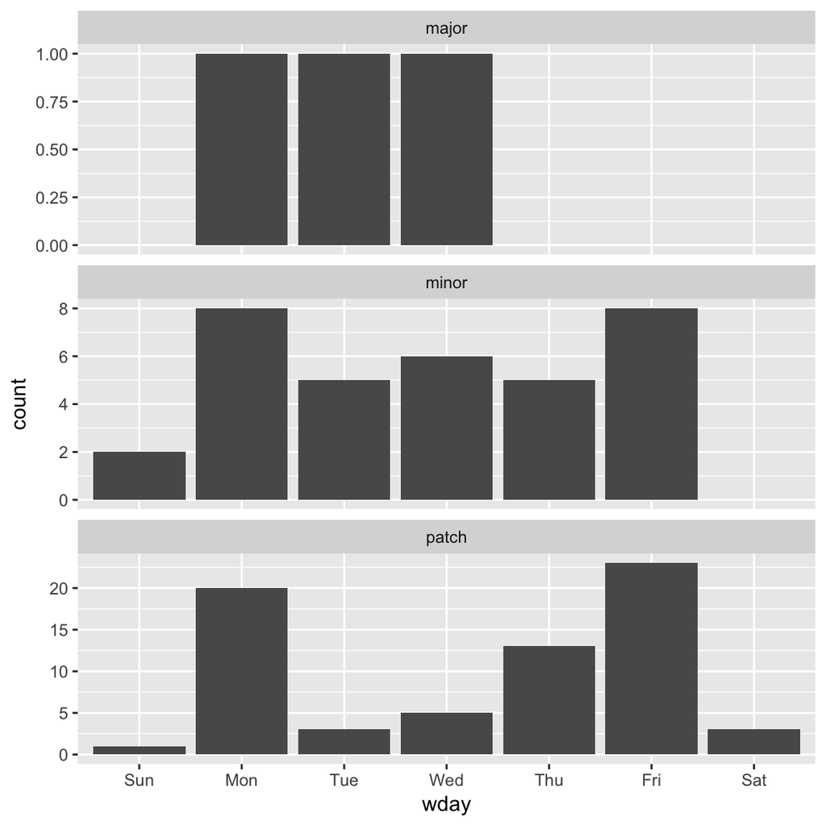

```r
# Plot barchart of weekday by type of release
ggplot(releases, aes(wday)) +
  geom_bar() +
  facet_wrap(~ type, ncol = 1, scale = "free_y")
```

## Extraction for plotting

- Before we begin this exercise, let us load in `ggridges`
- you might need to install it.

```r
#install.packages("ggridges")
library(ggridges)
```

- Use `mutate()` to create three new columns: `year`, `yday` and `month` that respectively hold the same components of the date column. Don’t forget to label the months with their names.

```r
# Add columns for year, yday and month
akl_daily <- akl_daily %>%
  mutate(
    year = ___(date),
    yday = ___(date),
    month = ___(date, label = TRUE))
```

```r
# Add columns for year, yday and month
akl_daily <- akl_daily %>%
  mutate(
    year = year(date),
    yday = yday(date),
    month = month(date, label = TRUE))
```

```r
akl_daily
```

[output not shown]

- Create a plot of yday on the x-axis, max_temp of the y-axis where lines are grouped by year. Each year is a line on this plot, with the x-axis running from Jan 1 to Dec 31.

```r
ggplot(akl_daily, aes(x = yday, y = max_temp)) +
  geom_line(aes(group = year), alpha = 0.5)
```

[output not shown]

- To take an alternate look, create a ridgeline plot(formerly known as a joyplot) with max_temp on the x-axis, month on the y-axis, using geom_density_ridges() from the ggridges package.

```r
# Examine distribtion of max_temp by month
ggplot(akl_daily, aes(x = max_temp, y = month, height = ..density..)) +
  geom_density_ridges(stat = "density")
```

[output not shown]

## Extracting for filtering and summarizing

- Create new columns for the hour and month of the observation from datetime. Make sure you label the month

```r
# Create new columns hour, month and rainy
akl_hourly <- akl_hourly %>%
  mutate(
    hour = hour(datetime),
    month = month(datetime, label = TRUE),
    rainy = weather == "Precipitation"
  )
```

```r
# Filter for hours between 8am and 10pm (inclusive)
akl_day <- akl_hourly %>%
  filter(hour >= 8, hour <= 22)
```

- Group the observations first by month, then by date and summarise by using any() on the rainy column

```r
# Summarise for each date if there is any rain
rainy_days <- akl_day %>%
  group_by(month, date) %>%
  summarise(
    any_rain = any(rainy)
  )
```

- Summarise again by summing up any_rainy

```r
# Summarise for each month, the number of days with rain
rainy_days %>%
  summarise(
    days_rainy = sum(any_rain)
  )
```

```
## # A tibble: 12 x 2
##    month days_rainy
##    <ord>      <int>
##  1 Jan           15
##  2 Feb           13
##  3 Mar           12
##  4 Apr           15
##  5 May           21
##  6 Jun           19
##  7 Jul           22
##  8 Aug           16
##  9 Sep           25
## 10 Oct           20
## 11 Nov           19
## 12 Dec           11
```

## Rounding Datetimes

- It will result into another object of a same type

```r
release_time <- releases$datetime
head(release_time)
```

```
## [1] "1997-12-04 08:47:58 UTC" "1997-12-21 13:09:22 UTC"
## [3] "1998-01-10 00:31:55 UTC" "1998-03-14 19:25:55 UTC"
## [5] "1998-05-02 07:58:17 UTC" "1998-06-14 12:56:20 UTC"
```

```r
head(release_time) %>% hour()
```

```
## [1]  8 13  0 19  7 12
```

- If we use floor_date. It will result into something like this:

```r
head(release_time) %>% floor_date(unit = "hour")
```

```
## [1] "1997-12-04 08:00:00 UTC" "1997-12-21 13:00:00 UTC"
## [3] "1998-01-10 00:00:00 UTC" "1998-03-14 19:00:00 UTC"
## [5] "1998-05-02 07:00:00 UTC" "1998-06-14 12:00:00 UTC"
```

- In lubridate, there are 3 functions that does the rounding:

```r
#round_date() - rounds to the nearest
head(release_time) %>% round_date(unit = "hour")
```

```
## [1] "1997-12-04 09:00:00 UTC" "1997-12-21 13:00:00 UTC"
## [3] "1998-01-10 01:00:00 UTC" "1998-03-14 19:00:00 UTC"
## [5] "1998-05-02 08:00:00 UTC" "1998-06-14 13:00:00 UTC"
```

```r
#ceiling date() - rounds up
head(release_time) %>% ceiling_date(unit = "hour")
```

```
## [1] "1997-12-04 09:00:00 UTC" "1997-12-21 14:00:00 UTC"
## [3] "1998-01-10 01:00:00 UTC" "1998-03-14 20:00:00 UTC"
## [5] "1998-05-02 08:00:00 UTC" "1998-06-14 13:00:00 UTC"
```

floor_date() - rounds down

## Practice Rounding

Choose the right function and units to round r_3_4_1 down to the nearest day

Choose the right function and units to round r_3_4_1 to the nearest 5 minutes

Choose the right function and units to round r_3_4_1 up to the nearest week

Find the time elapsed on the day of release at the time of release by subtracting r_3_4_1 rounded down to the day from r_3_4_1

```r
r_3_4_1 <- ymd_hms("2016-05-03 07:13:28 UTC")
```

```r
# Round down to day
floor_date(r_3_4_1, unit = "day")
```

```
## [1] "2016-05-03 UTC"
```

```r
# Round to nearest 5 minutes
round_date(r_3_4_1, unit = "5 minutes")
```

```
## [1] "2016-05-03 07:15:00 UTC"
```

```r
# Round up to week
ceiling_date(r_3_4_1, unit = "week")
```

```
## [1] "2016-05-08 UTC"
```

```r
# Subtract r_3_4_1 rounded down to day
r_3_4_1 - floor_date(r_3_4_1, unit = "day")
```

```
## Time difference of 7.224444 hours
```

## Rounding with the weather data

Create a new column called `day_hour` that is datetime rounded down to the nearest hour

```r
# Create day_hour, datetime rounded down to hour
akl_hourly <- akl_hourly %>%
  mutate(
    day_hour = floor_date(datetime, unit = "hour")
  )
```

Use count() on day_hour to count how many observations there are in each hour

```r
# Count observations per hour
akl_hourly %>%
  count(day_hour)
```

```
## # A tibble: 8,770 x 2
##    day_hour                n
##    <dttm>              <int>
##  1 2016-01-01 00:00:00     2
##  2 2016-01-01 01:00:00     2
##  3 2016-01-01 02:00:00     2
##  4 2016-01-01 03:00:00     2
##  5 2016-01-01 04:00:00     2
##  6 2016-01-01 05:00:00     2
##  7 2016-01-01 06:00:00     2
##  8 2016-01-01 07:00:00     2
##  9 2016-01-01 08:00:00     2
## 10 2016-01-01 09:00:00     2
## # … with 8,760 more rows
```

Extend the pipeline so that after counting, you filter for observations where n is not equal to 2

```r
# Find day_hours with n != 2
akl_hourly %>%
  count(day_hour) %>%
  filter(n != 2) %>%
  arrange(desc(n))
```

```
## # A tibble: 92 x 2
##    day_hour                n
##    <dttm>              <int>
##  1 2016-04-03 02:00:00     4
##  2 2016-09-25 00:00:00     4
##  3 2016-06-26 09:00:00     1
##  4 2016-09-01 23:00:00     1
##  5 2016-09-02 01:00:00     1
##  6 2016-09-04 11:00:00     1
##  7 2016-09-04 16:00:00     1
##  8 2016-09-04 17:00:00     1
##  9 2016-09-05 00:00:00     1
## 10 2016-09-05 15:00:00     1
## # … with 82 more rows
```